[figure not shown]

PS(diag)-9

Control Module I/O Signal

POWER ASSISTED SYSTEM (POWER STEERING) (DIAGNOSTICS)

5. Control Module I/O Signal

A: ELECTRICAL SPECIFICATION

NOTE:

The terminal numbers of the power steering control module connectors are as indicated in the figure.

Contents Terminal No.

Input/output signal

Measured value and measuring conditions

Power supply (IG SW) A1

between A1 — B1.

Shield GND A3 0 V is constantly detected.

Main torque sensor A4

ignition switch ON.

Sub torque sensor A5

ignition switch ON.

CAN communication A6 Digital signal; can not be measured

CAN communication A7 Digital signal; can not be measured

Torque sensor ground A9 0 V is constantly detected.

Torque sensor power supply A10 Approximately 5 V is detected with ignition switch ON.

Ground B1

Battery voltage is constantly detected when measuring between B1 — B2.

Power supply B2

Resolver S1 C1

Varies depending on the operational status of the motor.

Resolver S3 C2

Resolver S2 C3

Resolver S4 C4

Resolver R1 C5

Resolver R2 C6

Motor W phase D1

Motor U phase D3

PS-01741

4

5

10

2

1

3

2

1

4

5

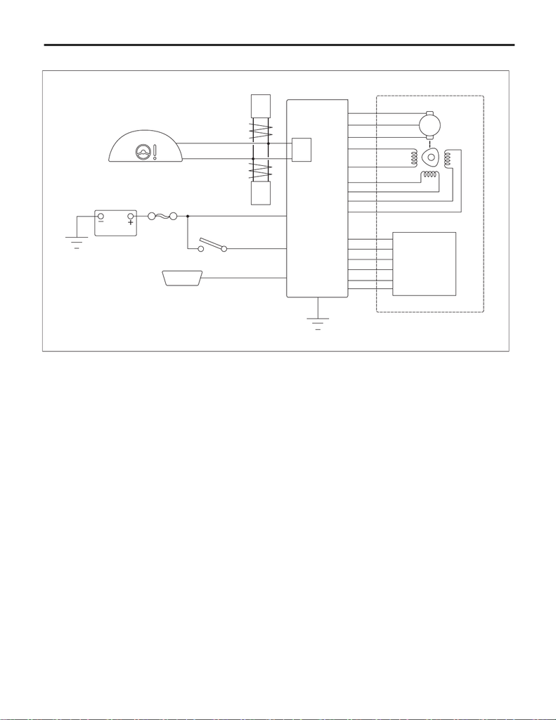

PS(diag)-10

Control Module I/O Signal

POWER ASSISTED SYSTEM (POWER STEERING) (DIAGNOSTICS)

B: WIRING DIAGRAM

(1) Battery (5) Engine control module (ECM) (9) Torque sensor (main & sub)

(2) Ignition switch (6) Power steering control module (10) CAN communication

nation meter)

(7) Motor (11) VDC CM

(4) Data link connector (for Subaru

Select Monitor)

(8) Resolver sensor (12) Steering gearbox

PS-01748

(1)

(2)

(3)

(4)

(5)

(11)

(6)

(7)

(8)

(12)

(9)

(10)